# Tema 3. Flujo de datos

Programación en Tecnologías de la Información Geográfica · Máster Universitario en Tecnologías de la Información Geográfica

Author

Paloma Ruiz Benito, Verónica Cruz Alonso, Marina Rodes Blanco

Published

22/10/2026

## 1 Objetivos Tema3: Flujo y control

- Organizando datos: gramática de datos (📝)
- Visualización de datos: ggplot (🧑‍🎓 )

### 1.1 Gramática de datos

En el tema anterior trabajamos con las funciones `filter()` / `slice()` y `select()` y `rename()`. En este tema vamos a trabajar con el resto de funciones básicas de `dplyr`.

`distinct`: filtra por filas únicas.

`mutate`: operaciones con variables, añadiendo nuevas.

`summarise`: reduce variables a valores (estadísticas).

`group_by`: operaciones que requieren agrupación.

### 1.2 Transformar los datos y calcular nuevas variables

#### 1.2.1 [Mutate](https://dplyr.tidyverse.org/reference/mutate.html): crear, modificar o eliminar columnas

Primero, volvemos a leer la base de datos de tidytuesday de **cousine**; despues:

- generamos una nueva variable que contiene un identificador único,
- una nueva variable que sea n valor del número de usuarios que han valorado una receta, pero no han escrito una reseña o comentario (i.e. número de reseñas al numero total de valoraciones).
- redefinir `servings` considerando los niveles del factor, cambiando de `1`, `2` y `3` a `una_persona`, `dos_personas` y `tres_personas`.

```r
library(tidyverse)

recetas <- read_delim(file = "data/cuisines.csv",
                      delim = ",")
# con el argumento col_type puedo especificar el tipo de dato (en este caso country como factor)

recetas <- read_delim(
  file = "data/cuisines.csv",
  delim = ",",
  col_type = list(country = "f", servings = "f")
)

recetas
```

```
# A tibble: 2,218 × 17
   name     country url   author date_published ingredients calories   fat carbs
   <chr>    <fct>   <chr> <chr>  <date>         <chr>          <dbl> <dbl> <dbl>
 1 Saganak… Greek   http… John … 2024-02-07     1 (4 ounce…      391    25    15
 2 Coney I… Jewish  http… John … 2024-11-26     2 ¾ cups a…      301    17    31
 3 Diana's… Austra… http… CHIPP… 2022-07-14     1 ½ cups w…       64     3     9
 4 Chilean… Chilean http… Heidi  2025-01-31     ½ cup chop…      106     9     7
 5 Tex-Mex… Tex-Mex http… Ann    2025-02-18     2 cups all…      449    23    58
 6 Newfoun… Canadi… http… MomWh… 2022-08-12     1 (3 pound…      958    24   144
 7 Pasta e… Italian http… Buckw… 2023-12-12     1 cup dry …      378    10    59
 8 Danish … Danish  http… TheOt… 2020-06-19     4 cups all…       90     5    10
 9 Lemon P… Amish … http… Laura… 2025-01-21     2 cups all…      157     6    25
10 Pan con… Spanish http… Luis … 2025-06-02     1 large to…      322    16    39
# ℹ 2,208 more rows
# ℹ 8 more variables: protein <dbl>, avg_rating <dbl>, total_ratings <dbl>,
#   reviews <dbl>, prep_time <dbl>, cook_time <dbl>, total_time <dbl>,
#   servings <fct>
```

```r
summary(recetas)
```

```
        name                              country            url
 Length   :2218   Canadian                    :  67   Length   :2218
 N.unique :2216   Brazilian                   :  67   N.unique :2218
 N.blank  :   0   Filipino                    :  66   N.blank  :   0
 Min.nchar:   4   Australian and New Zealander:  65   Min.nchar:  45
 Max.nchar:  87   Cuban                       :  65   Max.nchar: 120
                  Chinese                     :  65
                  (Other)                     :1823
       author     date_published          ingredients      calories
 Length   :2218   Min.   :2009-02-09   Length   :2218   Min.   :   3.0
 N.unique :1635   1st Qu.:2022-11-02   N.unique :2217   1st Qu.: 190.0
 N.blank  :   0   Median :2024-07-14   N.blank  :   0   Median : 319.5
 Min.nchar:   1   Mean   :2023-10-27   Min.nchar:  29   Mean   : 358.4
 Max.nchar:  35   3rd Qu.:2025-01-06   Max.nchar:1109   3rd Qu.: 477.0
                  Max.   :2025-07-29   NAs      :   1   Max.   :2266.0
                                                        NAs    :32
      fat             carbs           protein         avg_rating
 Min.   :  0.00   Min.   :  1.00   Min.   :  0.00   Min.   :1.000
 1st Qu.:  7.00   1st Qu.: 13.00   1st Qu.:  4.00   1st Qu.:4.300
 Median : 15.00   Median : 26.00   Median : 11.00   Median :4.600
 Mean   : 18.76   Mean   : 31.96   Mean   : 16.61   Mean   :4.509
 3rd Qu.: 26.00   3rd Qu.: 45.00   3rd Qu.: 25.00   3rd Qu.:4.800
 Max.   :225.00   Max.   :264.00   Max.   :159.00   Max.   :5.000
 NAs    :55       NAs    :35       NAs    :39       NAs    :97
 total_ratings       reviews         prep_time        cook_time
 Min.   :  1.00   Min.   :  1.00   Min.   :   0.0   Min.   :  0.00
 1st Qu.:  6.00   1st Qu.:  6.00   1st Qu.:  10.0   1st Qu.: 10.00
 Median : 24.00   Median : 21.00   Median :  15.0   Median : 25.00
 Mean   : 85.25   Mean   : 76.93   Mean   :  21.5   Mean   : 41.75
 3rd Qu.: 87.00   3rd Qu.: 74.00   3rd Qu.:  25.0   3rd Qu.: 45.00
 Max.   :997.00   Max.   :975.00   Max.   :1800.0   Max.   :600.00
 NAs    :97       NAs    :108
   total_time       servings
 Min.   :    0   4      :487
 1st Qu.:   35   6      :419
 Median :   60   8      :396
 Mean   :  171   12     :238
 3rd Qu.:  120   10     :104
 Max.   :14440   (Other):572
                 NAs    :  2
```

```r
# definir una variable
recetas |>
  mutate(
    # desde cero
    ID = 1:nrow(recetas),
    # utilizando una variable para calcular otra (ej.nº personas con puntuación cero)
    num_ratings_no_review = total_ratings - reviews) |>
    select(ID,
          name:date_published,
          total_ratings,
          reviews,
          num_ratings_no_review,
          everything() #añade todas las columnas restantes, sin duplicar las ya seleccionadas.
        )
```

```
# A tibble: 2,218 × 19
      ID name          country url   author date_published total_ratings reviews
   <int> <chr>         <fct>   <chr> <chr>  <date>                 <dbl>   <dbl>
 1     1 Saganaki (Fl… Greek   http… John … 2024-02-07                25      22
 2     2 Coney Island… Jewish  http… John … 2024-11-26                10       9
 3     3 Diana's Hawa… Austra… http… CHIPP… 2022-07-14               126     104
 4     4 Chilean Pebre Chilean http… Heidi  2025-01-31                 1       1
 5     5 Tex-Mex Shee… Tex-Mex http… Ann    2025-02-18                13      11
 6     6 Newfoundland… Canadi… http… MomWh… 2022-08-12                40      32
 7     7 Pasta e Ceci… Italian http… Buckw… 2023-12-12                 3       3
 8     8 Danish Butte… Danish  http… TheOt… 2020-06-19                NA      NA
 9     9 Lemon Poppy … Amish … http… Laura… 2025-01-21                65      55
10    10 Pan con Toma… Spanish http… Luis … 2025-06-02                 2       2
# ℹ 2,208 more rows
# ℹ 11 more variables: num_ratings_no_review <dbl>, ingredients <chr>,
#   calories <dbl>, fat <dbl>, carbs <dbl>, protein <dbl>, avg_rating <dbl>,
#   prep_time <dbl>, cook_time <dbl>, total_time <dbl>, servings <fct>
```

```r
# sobreescribir una variable.
recetas |>
  mutate(
  # fct_recode sirve para redefinir los niveles de un factor (ojo                  sintaxis:new_name = "old_name")
    servings = fct_recode(
      servings,
      una_persona = "1" ,
      dos_personas = "2",
      tres_personas = "3"
      ))
```

```
# A tibble: 2,218 × 17
   name     country url   author date_published ingredients calories   fat carbs
   <chr>    <fct>   <chr> <chr>  <date>         <chr>          <dbl> <dbl> <dbl>
 1 Saganak… Greek   http… John … 2024-02-07     1 (4 ounce…      391    25    15
 2 Coney I… Jewish  http… John … 2024-11-26     2 ¾ cups a…      301    17    31
 3 Diana's… Austra… http… CHIPP… 2022-07-14     1 ½ cups w…       64     3     9
 4 Chilean… Chilean http… Heidi  2025-01-31     ½ cup chop…      106     9     7
 5 Tex-Mex… Tex-Mex http… Ann    2025-02-18     2 cups all…      449    23    58
 6 Newfoun… Canadi… http… MomWh… 2022-08-12     1 (3 pound…      958    24   144
 7 Pasta e… Italian http… Buckw… 2023-12-12     1 cup dry …      378    10    59
 8 Danish … Danish  http… TheOt… 2020-06-19     4 cups all…       90     5    10
 9 Lemon P… Amish … http… Laura… 2025-01-21     2 cups all…      157     6    25
10 Pan con… Spanish http… Luis … 2025-06-02     1 large to…      322    16    39
# ℹ 2,208 more rows
# ℹ 8 more variables: protein <dbl>, avg_rating <dbl>, total_ratings <dbl>,
#   reviews <dbl>, prep_time <dbl>, cook_time <dbl>, total_time <dbl>,
#   servings <fct>
```

```r
#utilizar mas de una variable para generar otra
recetas |>
  mutate(
    classification = case_when(
      # utilizar varias variables para calcular otra nueva
      avg_rating > 4 &
        country %in% c(
          "Chilean",
          "Brazilian",
          "Peruvian",
          "Cuban",
          "Puerto Rican",
          "Colombian"
        )  ~ "highest‑rated_Latin_cuisine",

      avg_rating < 2 &
        country %in% c(
          "Chilean",
          "Brazilian",
          "Peruvian",
          "Cuban",
          "Puerto Rican",
          "Colombian"
        )  ~ "lowest‑rated_Latin_cuisine",

      TRUE ~ "others" #resto de casos
    )
  )
```

```
# A tibble: 2,218 × 18
   name     country url   author date_published ingredients calories   fat carbs
   <chr>    <fct>   <chr> <chr>  <date>         <chr>          <dbl> <dbl> <dbl>
 1 Saganak… Greek   http… John … 2024-02-07     1 (4 ounce…      391    25    15
 2 Coney I… Jewish  http… John … 2024-11-26     2 ¾ cups a…      301    17    31
 3 Diana's… Austra… http… CHIPP… 2022-07-14     1 ½ cups w…       64     3     9
 4 Chilean… Chilean http… Heidi  2025-01-31     ½ cup chop…      106     9     7
 5 Tex-Mex… Tex-Mex http… Ann    2025-02-18     2 cups all…      449    23    58
 6 Newfoun… Canadi… http… MomWh… 2022-08-12     1 (3 pound…      958    24   144
 7 Pasta e… Italian http… Buckw… 2023-12-12     1 cup dry …      378    10    59
 8 Danish … Danish  http… TheOt… 2020-06-19     4 cups all…       90     5    10
 9 Lemon P… Amish … http… Laura… 2025-01-21     2 cups all…      157     6    25
10 Pan con… Spanish http… Luis … 2025-06-02     1 large to…      322    16    39
# ℹ 2,208 more rows
# ℹ 9 more variables: protein <dbl>, avg_rating <dbl>, total_ratings <dbl>,
#   reviews <dbl>, prep_time <dbl>, cook_time <dbl>, total_time <dbl>,
#   servings <fct>, classification <chr>
```

```r
# Podemos hacer todo lo anterior concatenando todo el proceso y guardar el set de datos:

recetas_modif <- recetas |>
  mutate(
    ID = 1:nrow(recetas),

    num_ratings_no_review = total_ratings - reviews,

    servings = fct_recode(
      servings,
      una_persona = "1" ,
      dos_personas = "2",
      tres_personas = "3")
  )


recetas_modif <- recetas |>
  mutate(
    ID = 1:nrow(recetas),

    num_ratings_no_review = total_ratings - reviews,

    servings = fct_recode(
      servings,
      una_persona = "1" ,
      dos_personas = "2",
      tres_personas = "3"),

    classification = case_when(
      # utilizar varias variables para calcular otra nueva
      avg_rating > 4 &
        country %in% c(
          "Chilean",
          "Brazilian",
          "Peruvian",
          "Cuban",
          "Puerto Rican",
          "Colombian")  ~ "highest‑rated_Latin_cuisine",

      avg_rating < 2 &
        country %in% c(
          "Chilean",
          "Brazilian",
          "Peruvian",
          "Cuban",
          "Puerto Rican",
          "Colombian")  ~ "lowest‑rated_Latin_cuisine",

      TRUE ~ "others" #resto de casos
    )
  )
```

#### 1.2.2 📝 *Ejercicio: mutate()*

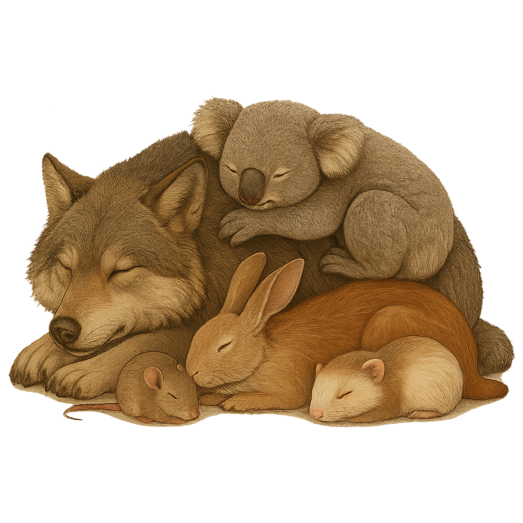

- Con el data set de msleep, incluye una nueva columna con el porcentaje de horas que duerme cada animal al día.
- Haz una clasificación que incluya tres categorías: carnivoros amenazados, herviboros amenazados y otros. Para ello tienes que basarte en las columnas “vore” y “conservation”. Segun la UICN se considera amenazado cuando está en las categorías vulnerable (vu), endangered (en) o critically endangered (cd).

#### 1.2.3 [Summarise](https://dplyr.tidyverse.org/reference/summarise.html) y [group by](https://dplyr.tidyverse.org/reference/group_by.html): generar un nuevo `data.frame` resumiendo cada grupo a una fila

```r
# mínimo y máximo tiempo de preparación
recetas |>
  summarise(prep_time_max = max(prep_time),
            prep_time_total_min = min(prep_time))
```

```
# A tibble: 1 × 2
  prep_time_max prep_time_total_min
          <dbl>               <dbl>
1          1800                   0
```

```r
# minimo, máximo y media de proteínas de todas las recetas
recetas |>
  summarise(protein_max = max(protein),
            protein_mean = mean(protein),
            protein_min = min(protein))
```

```
# A tibble: 1 × 3
  protein_max protein_mean protein_min
        <dbl>        <dbl>       <dbl>
1          NA           NA          NA
```

```r
 ## Ojo! si no queremos que tenga en cuenta los NA hay que añadir argumento na.rm = T
recetas |>
  summarise(protein_max = max(protein, na.rm = T),
            protein_mean = mean(protein, na.rm = T),
            protein_min = min(protein, na.rm = T))
```

```
# A tibble: 1 × 3
  protein_max protein_mean protein_min
        <dbl>        <dbl>       <dbl>
1         159         16.6           0
```

¿Cómo podríamos hacer lo mismo por país? Esta es una operación muy común gestionando datos: revisalo en la chuleta de dplyr.

```r
#Lo mismo que antes, pero por país
recetas |>
  group_by(country) |>
  summarise(protein_max = max(protein, na.rm=T),
            protein_mean = mean(protein, na.rm=T),
            protein_min = min(prep_time, na.rm=T))
```

```
# A tibble: 49 × 4
   country                      protein_max protein_mean protein_min
   <fct>                              <dbl>        <dbl>       <dbl>
 1 Greek                                 65        15.9            5
 2 Jewish                                62        11.7            0
 3 Australian and New Zealander          27         4.61           0
 4 Chilean                               54        12.3            0
 5 Tex-Mex                               56        23.2            0
 6 Canadian                              58        15.3            0
 7 Italian                               91        25.4            5
 8 Danish                                35         7.61           5
 9 Amish and Mennonite                   69         8.92           0
10 Spanish                               95        19.9            0
# ℹ 39 more rows
```

#### 1.2.4 📝 *Ejercicio: group_by(), summarise()*

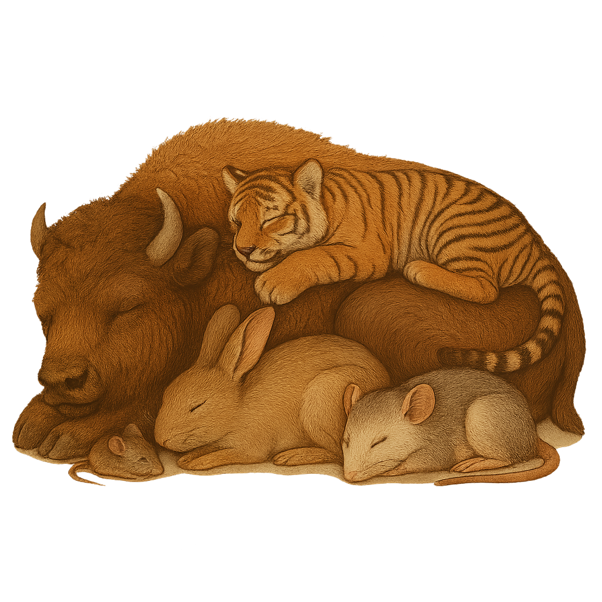

- Con el data set de msleep, cuenta el número de especies estudiadas por orden (order)
- Calcula el promedio de horas de sueño según el tipo de alimentación ¿duemen mas los carnivoros, los herbívoros o los insectívoros estudiados en este dataset?

### 1.3 [Pivot](https://tidyr.tidyverse.org/reference/pivot_longer.html): transformar datos a formato largo o ancho

Nos permite transformar datos de formato largo a ancho y viceversa. Nos puede convenir una forma u otra según lo que queramos hacer con lo datos: presentarlos en una tabla, hacer transformaciones o análisis, hacer un gráfico etc.

En la siguiente imagen, extraída de [The Epidemiologist R Handbook](https://www.epirhandbook.com/en/) se puede ver en qué consiste esta transformación.

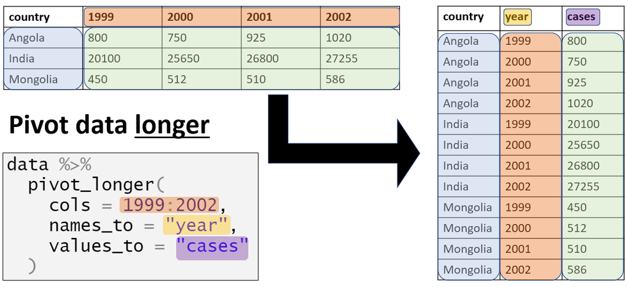

Pivot data transformation

```r
recetas_Vietnam<- recetas |>
  select(name, country, fat, carbs,protein) |>
  filter(country == "Vietnamese")

# transformamos a formato largo, incluyendo los valores de grasas, carbohidratos y proteinas en una columna llamada "nutritional_value

recetas_Vietnam_long <- recetas_Vietnam |>
  pivot_longer(cols = fat:protein,
               names_to = "nutritional_value")

#volvemos al set original

recetas_Vietnam_wide <- recetas_Vietnam_long |>
  pivot_wider(names_from = nutritional_value,
              values_from = value)
```

#### 1.3.1 📝🚀 *Ejercicio extra: transformar datos largo ancho*

[figure not shown]

- Lee el set de datos pixar_public_response_long. En este set de datos se encuentra la puntuación de películas pixar por la audiencia según tres webs diferentes: rotten tomatoes, metacritic y critics’ choice.
- Reorganiza el set de datos para que la puntuación de cada una de las webs se encuentre en una columna diferente
- (extra) ¿Cual es el promedio de puntuación por película teniendo en cuenta todas las fuentes? ¿Que película es la mejor y peor puntuada de media?

Fuente imagen: https://www.flickr.com/photos/harshlight/17294952412 (CC BY 2.0)

### 1.4 Unir data.frames: [joins](https://dplyr.tidyverse.org/reference/mutate-joins.html)

`*_join()` añade columnas de `y` (segundo data.frame) a `x` (primer data.frame), haciendo coincidir las observaciones en función de la variable común.

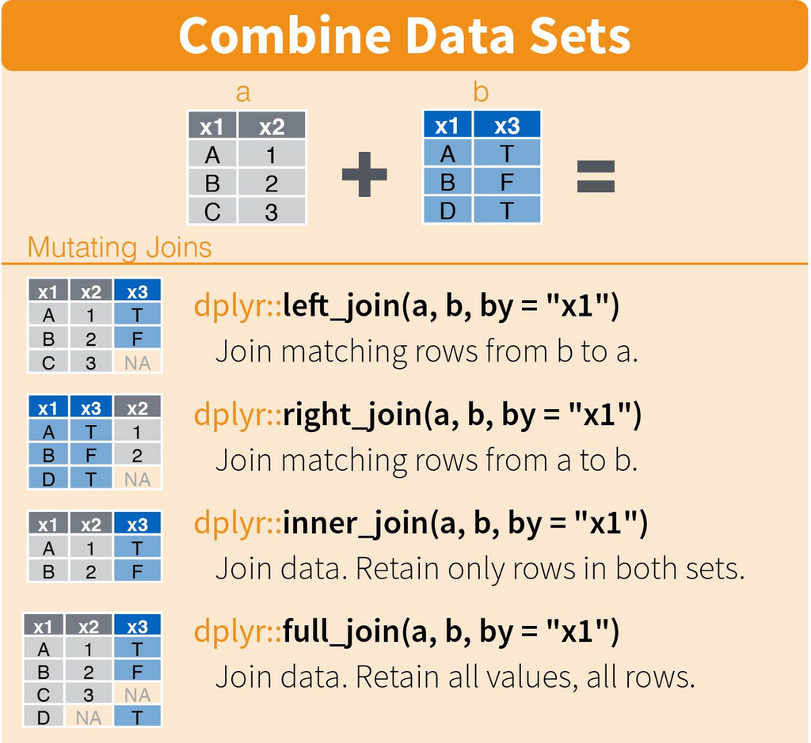

```r
# join: left, right, full, inner

#datos de pais - capital- continente
paises <- tibble(
  pais = c("España", "Francia", "Japón", "Brasil", "Sudáfrica"),
  capital = c("Madrid", "París", "Tokio", "Brasilia", "Pretoria"),
  continente = c("Europa", "Europa", "Asia", "América", "África")
)

#datos demográficos
demografia <- tibble(
  pais = c("España", "Japón", "Brasil", "Canadá", "Sudáfrica"),
  poblacion_millones = c(47.4, 125.7, 203.1, 39.6, 60.0),
  extension_km2 = c(505990, 377975, 8515767, 9984670, 1221037)
)

#left join: se une al set de datos de pais los datos de demografia (si los hay)
left_join(paises, demografia, by = "pais")
```

```
# A tibble: 5 × 5
  pais      capital  continente poblacion_millones extension_km2
  <chr>     <chr>    <chr>                   <dbl>         <dbl>
1 España    Madrid   Europa                   47.4        505990
2 Francia   París    Europa                   NA              NA
3 Japón     Tokio    Asia                    126.         377975
4 Brasil    Brasilia América                 203.        8515767
5 Sudáfrica Pretoria África                   60         1221037
```

```r
#right join: se une al set de datos de demografa los datos de pais (si los hay)
right_join(paises, demografia, by = "pais")
```

```
# A tibble: 5 × 5
  pais      capital  continente poblacion_millones extension_km2
  <chr>     <chr>    <chr>                   <dbl>         <dbl>
1 España    Madrid   Europa                   47.4        505990
2 Japón     Tokio    Asia                    126.         377975
3 Brasil    Brasilia América                 203.        8515767
4 Sudáfrica Pretoria África                   60         1221037
5 Canadá    <NA>     <NA>                     39.6       9984670
```

```r
#inner join: une los paises presentes en los dos set de datos
inner_join(paises, demografia, by = "pais")
```

```
# A tibble: 4 × 5
  pais      capital  continente poblacion_millones extension_km2
  <chr>     <chr>    <chr>                   <dbl>         <dbl>
1 España    Madrid   Europa                   47.4        505990
2 Japón     Tokio    Asia                    126.         377975
3 Brasil    Brasilia América                 203.        8515767
4 Sudáfrica Pretoria África                   60         1221037
```

```r
#full join: une todos los paises presentes en uno u otro.
paises_demo_full_join <- full_join(paises, demografia, by = "pais")
```

### 1.5 Guardar datos con [Write_delim](https://readr.tidyverse.org/reference/write_delim.html):

```r
write_delim(paises_demo_full_join,
            file = "resultados/paises_demo_full_join.csv",
            delim = ";")
```

#### 1.5.1 📝🚀 *Ejercicio: *_join() y exportar datos*

[figure not shown]

https://www.flickr.com/photos/harshlight/6988729286 (CC BY 2.0)

- Lee el set de datos pixar_public_response y pixar_films
- Explora los dos data sets con funciones como head() para ver las primeras lineas, glimpse() o View()
- Une ambos datasets en uno solo para tener en un mismo data frame toda la información. Elige el campo más apropiado de unión
- Guarda el nuevo set de datos como pixar_joint

## 2 Trabajando con palmerpenguins

Siempre vamos a trabajar con la pipa, y el primer argumento será una base de datos. Después tenemos que saber las **operaciones *qué queremos hacer***, para obtener una determinada base de datos de *salida*. Para todo el trabajo en esta sesión vamos a trabajar con la base de datos *palmerpenguins* que está disponible en el paquete palmerpenguins.

*¿Qué contiene?* Datos sobre tres especies de pingüinos (Adelie, Chinstrap y Gentoo) de las islas Palmer. Fue creasdo por Dr. Kristen Foram, Dr. Allinson Horst y Dr. Alison Hill, para exploración y visualización de datos.

[figure not shown]

Artwork by @allison_horst.

```r
library(palmerpenguins)
library(tidyverse)
glimpse(penguins)
```

```
Rows: 344
Columns: 8
$ species           <fct> Adelie, Adelie, Adelie, Adelie, Adelie, Adelie, Adel…
$ island            <fct> Torgersen, Torgersen, Torgersen, Torgersen, Torgerse…
$ bill_length_mm    <dbl> 39.1, 39.5, 40.3, NA, 36.7, 39.3, 38.9, 39.2, 34.1, …
$ bill_depth_mm     <dbl> 18.7, 17.4, 18.0, NA, 19.3, 20.6, 17.8, 19.6, 18.1, …
$ flipper_length_mm <int> 181, 186, 195, NA, 193, 190, 181, 195, 193, 190, 186…
$ body_mass_g       <int> 3750, 3800, 3250, NA, 3450, 3650, 3625, 4675, 3475, …
$ sex               <fct> male, female, female, NA, female, male, female, male…
$ year              <int> 2007, 2007, 2007, 2007, 2007, 2007, 2007, 2007, 2007…
```

### 2.1 Trabajando con un data.frame

```r
penguins |>
   select(species, starts_with("bill_length_mm"), sex)
```

```
# A tibble: 344 × 3
   species bill_length_mm sex
   <fct>            <dbl> <fct>
 1 Adelie            39.1 male
 2 Adelie            39.5 female
 3 Adelie            40.3 female
 4 Adelie            NA   <NA>
 5 Adelie            36.7 female
 6 Adelie            39.3 male
 7 Adelie            38.9 female
 8 Adelie            39.2 male
 9 Adelie            34.1 <NA>
10 Adelie            42   <NA>
# ℹ 334 more rows
```

Hay una serie de funciones que pueden ayudar a seleccionar (ver en el power point), posteriormente lo disponemos en **orden desdencente** por la produndidad del pico.

```r
penguins |>
  select(species, bill_depth_mm, sex) |>
  arrange(desc(bill_depth_mm)) |>
  head()
```

```
# A tibble: 6 × 3
  species bill_depth_mm sex
  <fct>           <dbl> <fct>
1 Adelie           21.5 male
2 Adelie           21.2 male
3 Adelie           21.2 male
4 Adelie           21.1 male
5 Adelie           21.1 male
6 Adelie           21.1 male
```

Si en vez de *ver* las seis primeras filas, queremos **seleccionarlas**, podemos usar la función *slice* que selecciona filas basads en su posición. El uso de *slice* es más común en tidyverse y especialmente después de agrupar.

```r
penguins |>
  select(species, bill_depth_mm, sex) |>
  arrange(desc(bill_depth_mm)) |>
  slice(1:6)
```

```
# A tibble: 6 × 3
  species bill_depth_mm sex
  <fct>           <dbl> <fct>
1 Adelie           21.5 male
2 Adelie           21.2 male
3 Adelie           21.2 male
4 Adelie           21.1 male
5 Adelie           21.1 male
6 Adelie           21.1 male
```

En este caso no hay ninguna diferencia con el anterior, pero si quisieramos las **tres primeras filas de cada especie** podriamos hacer lo siguiente. Hay variaciones muy interesantes como tenéis en el power point asociado.

```r
penguins |>
  select(species, bill_depth_mm, sex) |>
  group_by(species)|>
  arrange(desc(bill_depth_mm)) |>
  slice(1:3)
```

```
# A tibble: 9 × 3
# Groups:   species [3]
  species   bill_depth_mm sex
  <fct>             <dbl> <fct>
1 Adelie             21.5 male
2 Adelie             21.2 male
3 Adelie             21.2 male
4 Chinstrap          20.8 male
5 Chinstrap          20.7 male
6 Chinstrap          20.3 male
7 Gentoo             17.3 male
8 Gentoo             17.3 male
9 Gentoo             17.1 male
```

Imaginate que en este caso queremos únicamente tener dos especies de las tres. En este caso podemos filtrar por múltiples condiciones:

```r
penguins |>
  select(species, bill_depth_mm, sex) |>
  filter(species %in% c("Adelie", "Gentoo"),
         sex == "female") |>
  group_by(species)|>
  arrange(desc(bill_depth_mm)) |>
  slice(1:3)
```

```
# A tibble: 6 × 3
# Groups:   species [2]
  species bill_depth_mm sex
  <fct>           <dbl> <fct>
1 Adelie           20.7 female
2 Adelie           19.3 female
3 Adelie           19.3 female
4 Gentoo           15.5 female
5 Gentoo           15.2 female
6 Gentoo           15.2 female
```

Vamos a ver cómo **contar** el número de individuos muestreados, con la funcion “count”

```r
penguins |>
  select(species, bill_depth_mm, sex) |>
  filter(species %in% c("Adelie", "Gentoo"),
         sex == "female") |>
  group_by(species)|>
  count()
```

```
# A tibble: 2 × 2
# Groups:   species [2]
  species     n
  <fct>   <int>
1 Adelie     73
2 Gentoo     58
```

Ahora, vamos a calcular la **media del tamaño del pico y la desviación estandar por especie**, añadiendolo a lo anterior con la función summarise(). Por favor, chequea que entiendes cómo **summarise** cambia la estructura del data.frame ya que colapsa las filas a cada valor dentro del “group_by” y remueve las columnas que son irrelevantes en el cálculo. Cuando se genera una nueva columna no es obligatorio pero es *MUY RECOMENDABLE* nombrarla con un estilo y sintaxis adecuado.

```r
penguins |>
  select(species, bill_depth_mm, sex) |>
  filter(species %in% c("Adelie", "Gentoo"),
         sex == "female") |>
  group_by(species)|>
  summarise(num_inds   = n(),
            mean_depth = mean(bill_depth_mm),
            sd_depth   = sd(bill_depth_mm))
```

```
# A tibble: 2 × 4
  species num_inds mean_depth sd_depth
  <fct>      <int>      <dbl>    <dbl>
1 Adelie        73       17.6    0.943
2 Gentoo        58       14.2    0.540
```

#### 2.1.1 📝 **📤**Ejercicio: calcula estadisticas y ordena. Envia “`3.1.summary_spp_sex.csv`” a través del aula virtual

Realiza los siguientes pasos:

1. Selecciona el data.frame `penguins`, y calcula con `mutate` dos nuevas variables que son la longitud y la profundidad del pico en metros. Guardalo en el df `penguins`.
2. Para cada especie calcula el numero de individuos hembras y machos.
3. Para los machos y hembras para cada especie calcula la media, el maximo, el mínimo y la desviación estandar de la longitud y profundidad del pico.
4. Exporta la tabla en la carpeta “resultados” nombrando a la tabla como `3.1.summary_spp_sex.csv`

### 2.2 Trabajando con un varios data frames: bases de datos y uniones

Imaginate que tenemos información adicional sobre las especies, pero solo a nivel de especie, que es *la edad promedio de reproducción* y queremos traerlo a este data.frame ¿cómo podríamos unir ambas bases de datos?

Antes de ponder realizar uniones tienes que poder entender qué es un identificador o **llave** tal y como se usa en el lenguaje de base de datos. Normalmente se trabajan con bases de datos que son un conjunto de tablas que se *relacionan* entre si. Cuando trabajes con datos tienes que entender cada **tabla** y como son las relaciones entre las tablas, para poder hacer uniones cuando lo necesites. Cada tabla tiene que tener un **identificador único** y si en tu base de datos tienes varias tablas que se relacionan entre si debes conocer y chequear las relaciones.

```r
edad_repro <- data.frame(
  species = c("Adelie", "Chinstrap", "Gentoo"),
  edad_reproduccion = c(3.5, 4.0, 5.0)
)
```

Unimos ambas bases de datos:

```r
penguins_joined <- penguins |>
  left_join(edad_repro, by = "species")
```

Inspeccionamos el resultado:

```r
penguins_joined |>
  select(species, sex, body_mass_g, edad_reproduccion) |>
  head()
```

```
# A tibble: 6 × 4
  species sex    body_mass_g edad_reproduccion
  <chr>   <fct>        <int>             <dbl>
1 Adelie  male          3750               3.5
2 Adelie  female        3800               3.5
3 Adelie  female        3250               3.5
4 Adelie  <NA>            NA               3.5
5 Adelie  female        3450               3.5
6 Adelie  male          3650               3.5
```

Como resultado el **left_join** mantiene todas las filas de la izquiera, pero *¿habría dado el mismo resultado con un right_join o full_join?*

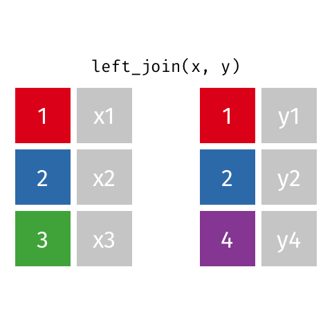

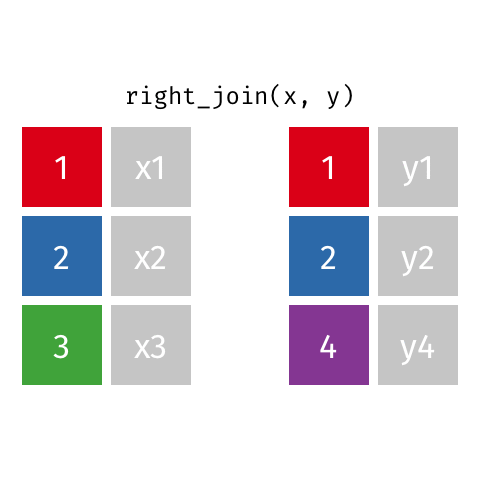

En ocasiones nos puede interesar realizar uniones completas con **full_join**, en ese caso se mantendrían todas las filas de ambas bases de datos, poniendo NAs si no tiene información disponible.

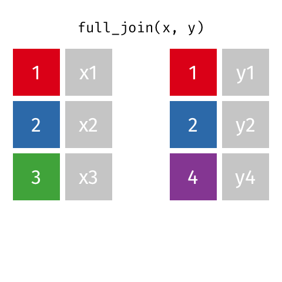

También podríamos hacer un **inner_join** si queremos que mantenga únicamente los identificadores que están en ambas bases de datos.

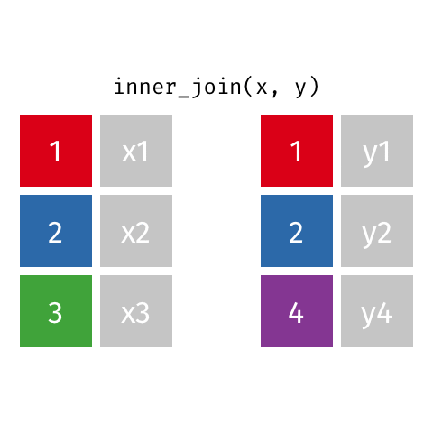

A modo resumen, aquí tienes **todos los tipos de uniones**.

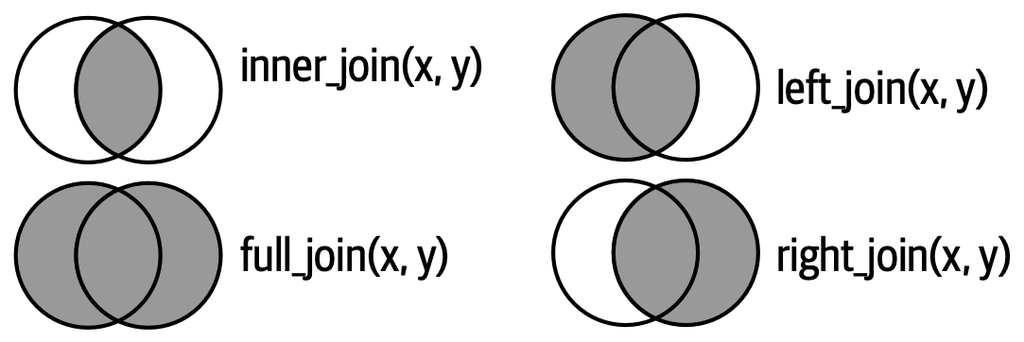

Os mostramos en línea para practicar manipulación y transformación de datos en R, especialmente con el **ecosistema tidyverse**. Cada enlace incluye ejercicios, datasets y explicaciones paso a paso.

[R for Data Science (Capítulo 3: Data transformation)](https://r4ds.hadley.nz/data-transform.html)

Guía oficial del libro *R for Data Science* (2ª edición).  
Incluye ejemplos detallados sobre los verbos principales de `dplyr`:  
`filter()`, `mutate()`, `arrange()`, `summarise()`, `group_by()` y `join()`.

[Learn the tidyverse – sitio oficial](https://www.tidyverse.org/learn/)

Portal oficial del *tidyverse*, con tutoriales, documentación y materiales de aprendizaje.  
Ofrece enlaces a recursos de `dplyr`, `ggplot2`, `tidyr`, `stringr`, `forcats`, etc.

[Interactive Tutorials • learnr](https://rstudio.github.io/learnr/)

Herramienta para crear y realizar **tutoriales interactivos** ejecutables dentro de RStudio.